# Tugas Praktikum 6

# 3.2 Uji ADF

```r
tseries::adf.test(train.diff)
```

```
##
##  Augmented Dickey-Fuller Test
##
## data:  train.diff
## Dickey-Fuller = -5.8001, Lag order = 5, p-value = 0.01
## alternative hypothesis: stationary
```

H0 : Data tidak stasioner dalam rataan H1 : Data stasioner dalam rataan p- Value sebesar 0.01 lebih kecil dari 0.05 sehingga Tolak H0 atau data stasioner dalam rataan.

```r
# 1. Sesuaikan panjang index karena differencing menghilangkan 1 observasi awal
index_diff <- seq(1:length(train.diff))

# Cek nilai minimum
min_val <- min(train.diff)
min_val
```

```
## [1] -49.3375
```

```r
# Jika ada nilai <= 0, tambahkan konstanta
if (min_val <= 0) {

  c <- abs(min_val) + 1

  train.diff_shifted <- train.diff + c

} else {

  train.diff_shifted <- train.diff

}
min(train.diff_shifted)
```

```
## [1] 1
```

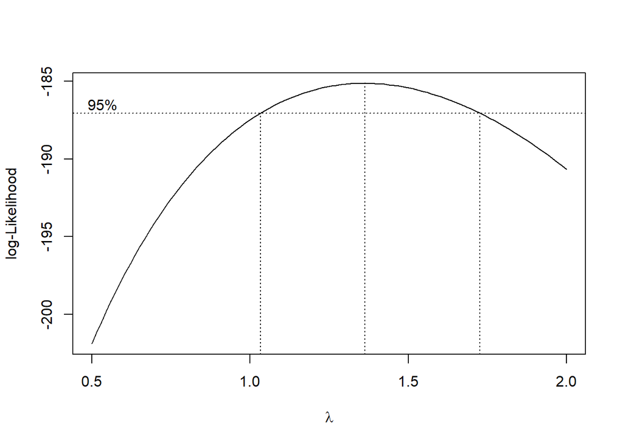

```r
# 3. Plot Box-Cox pada data yang sudah di-shift
bc_diff <- boxcox(
  train.diff_shifted ~ index_diff,
  lambda = seq(0.5, 2, by = 0.1)
)
```

```r
# 4. Nilai lambda optimum (rounded)
lambda_opt_diff <- bc_diff$x[which.max(bc_diff$y)]
print(paste("Lambda optimum setelah diff:", lambda_opt_diff))
```

```
## [1] "Lambda optimum setelah diff: 1.36363636363636"
```

```r
# 5. Selang kepercayaan 95% untuk lambda
ci_lambda_diff <- bc_diff$x[bc_diff$y > max(bc_diff$y) - 0.5 * qchisq(0.95, df = 1)]

# Batas bawah dan batas atas
ci_lower_diff <- min(ci_lambda_diff)
ci_upper_diff <- max(ci_lambda_diff)

c(Batas_Bawah = ci_lower_diff, Batas_Atas = ci_upper_diff)
```

```
## Batas_Bawah  Batas_Atas
##    1.045455    1.712121
```

# 4. Identifikasi Model

# 4.1 Plot ACF

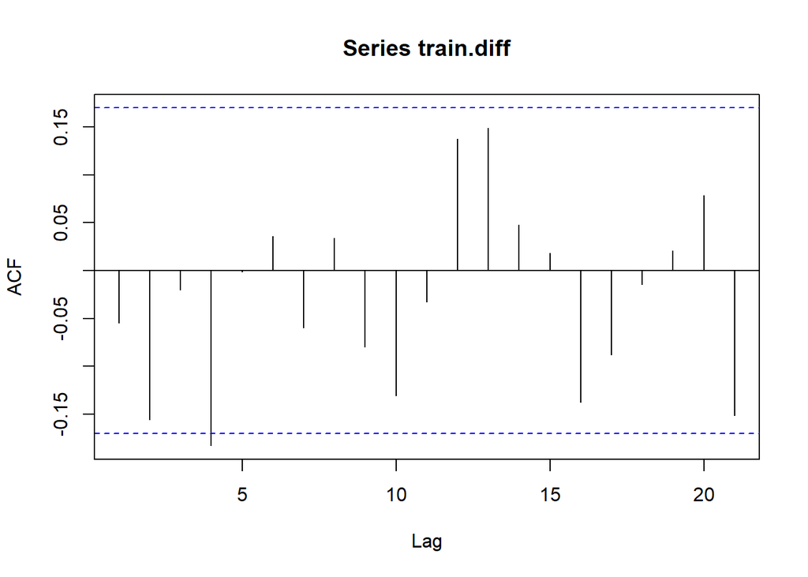

```r
acf(train.diff)
```

# 4.2 Plot PACF

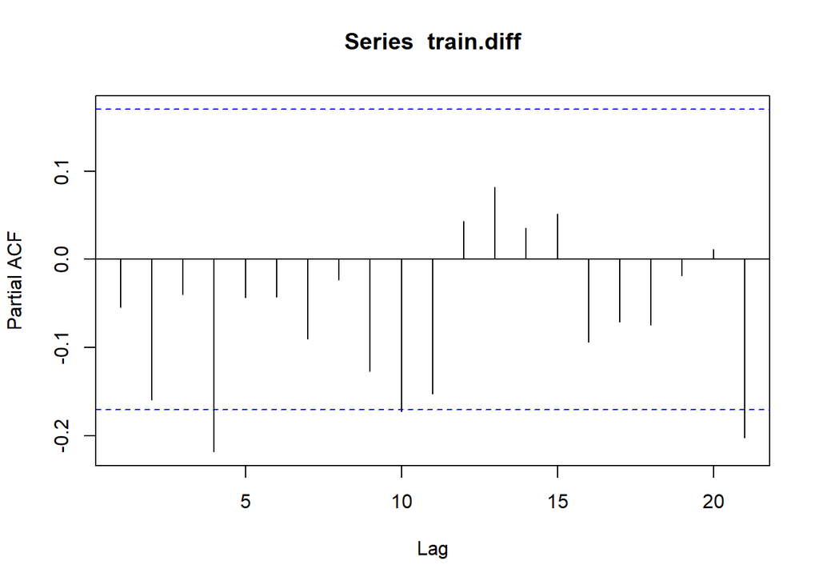

```r
pacf(train.diff)
```

terdapat beberapa spike yang melewati batas signifikansi, terutama pada lag ke-4 dan beberapa lag lainnya. Pola PACF tidak menunjukkan cut-off yang jelas pada lag awal sehingga orde AR belum dapat ditentukan secara langsung hanya berdasarkan PACF.

```r
library(TSA)
```

# 4.3 Plot EACF

```r
eacf(train.diff)
```

```
## AR/MA
##   0 1 2 3 4 5 6 7 8 9 10 11 12 13
## 0 o o o x o o o o o o o  o  o  o
## 1 x o o o o o o o o o o  o  o  o
## 2 x x o x o o o o o o o  o  o  o
## 3 o x o o o o o o o o o  o  o  o
## 4 o o x o o o o o o o o  o  o  o
## 5 x o x o o o o o o o o  o  o  o
## 6 x x o o o o o o o o o  o  o  o
## 7 o x x o o o x o o o o  o  o  o
```